# Electoral Commission digital imprints experiment

#### Plotting: model predictions

#### Model assumptions

Assumptions checked:

- Normality of residuals
- Variance of residuals
- Normality of residuals for the random effects

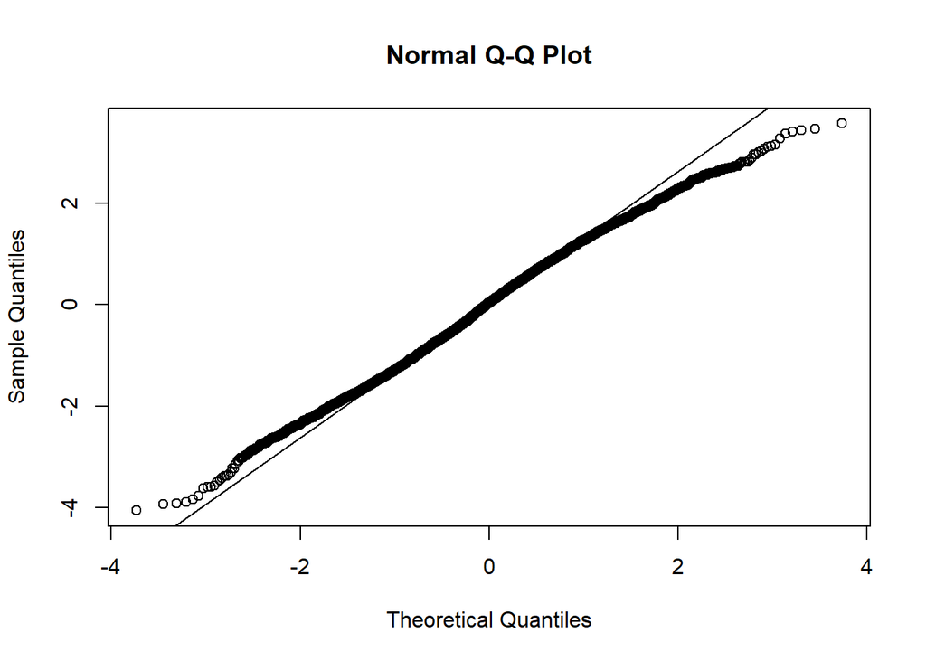

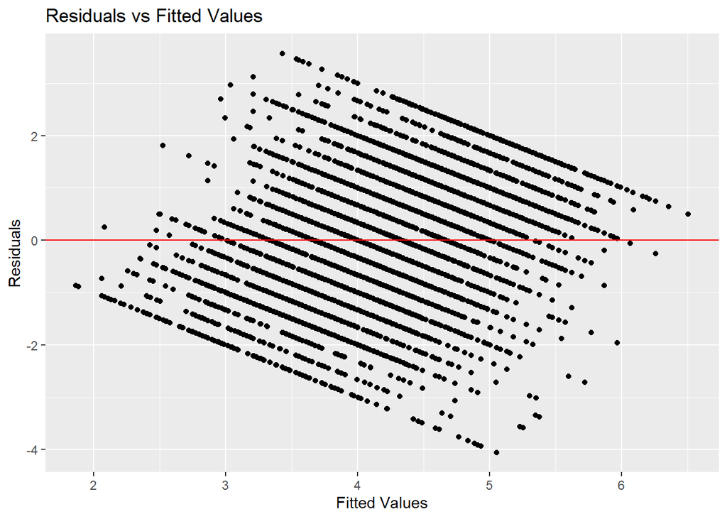

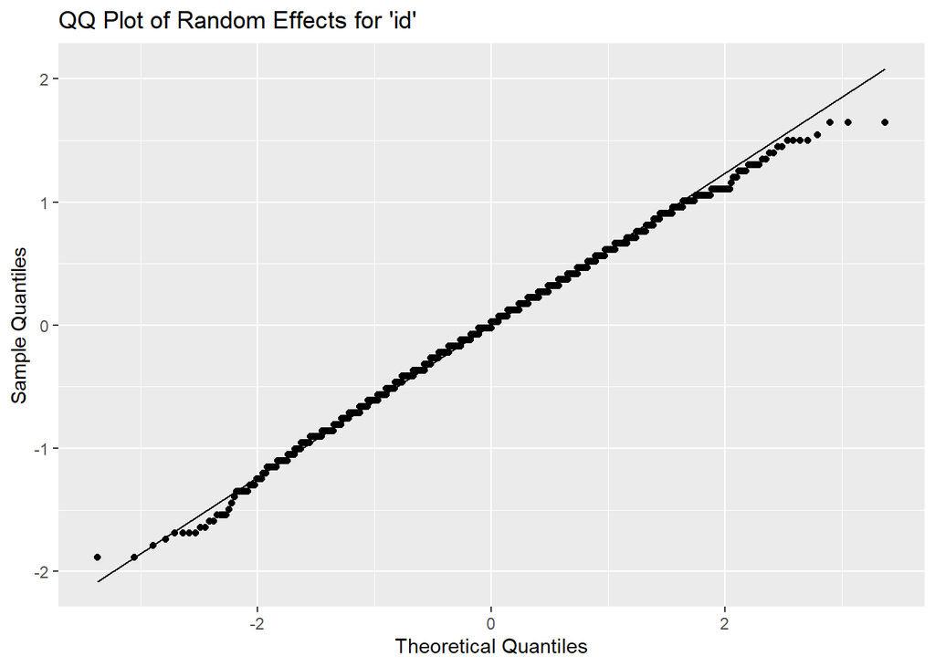

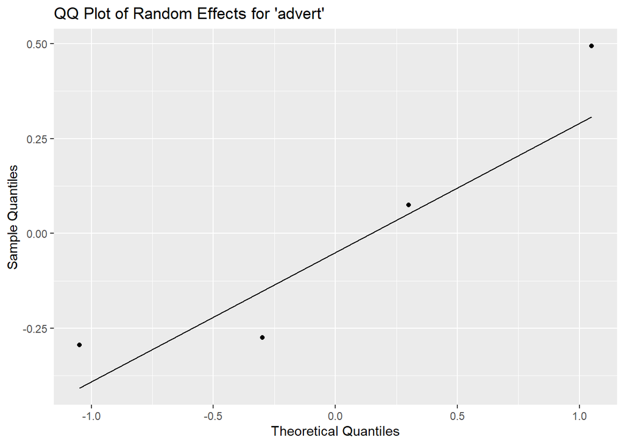

```
##
##  Shapiro-Wilk normality test
##
## data:  id_effects
## W = 0.99724, p-value = 0.02143
```

```
##
##  Shapiro-Wilk normality test
##
## data:  advert_effects
## W = 0.87433, p-value = 0.315
```

#### Supplementary analysis: advert level variations on informedness

Is there evidence to suggest that it is the aesthetic style and content of an advert itself that increases informedness about a source, and do digital imprints play a role in informing citizens above and beyond this?

Claims tested:

- Informedness about the source will be increased by the presence of a digital imprint, even when accounting for variations in campaign material content and format.

To further explore this, we can conduct an analysis comparing the effect of viewing each campaign post with and without the inclusion of a digital imprint on persuasion knowledge, political goal recognition, and perceived informedness.

Decriptive bivariate statistics for percieved persuasion knowledge

| advert | version | n | mean_pk | sd_pk | se_pk | ci_upper | ci_lower |
| --- | --- | --- | --- | --- | --- | --- | --- |
| advert.1 | 0 | 665 | 5.40 | 0.95 | 0.04 | 5.47 | 5.33 |
| advert.1 | 1 | 657 | 5.51 | 0.98 | 0.04 | 5.58 | 5.43 |
| advert.2 | 0 | 657 | 4.91 | 1.00 | 0.04 | 4.99 | 4.84 |
| advert.2 | 1 | 665 | 5.04 | 1.01 | 0.04 | 5.12 | 4.97 |
| advert.3 | 0 | 662 | 4.42 | 1.01 | 0.04 | 4.50 | 4.35 |
| advert.3 | 1 | 660 | 4.59 | 1.02 | 0.04 | 4.67 | 4.51 |
| advert.4 | 0 | 660 | 4.47 | 0.94 | 0.04 | 4.54 | 4.40 |
| advert.4 | 1 | 662 | 4.47 | 0.98 | 0.04 | 4.54 | 4.39 |

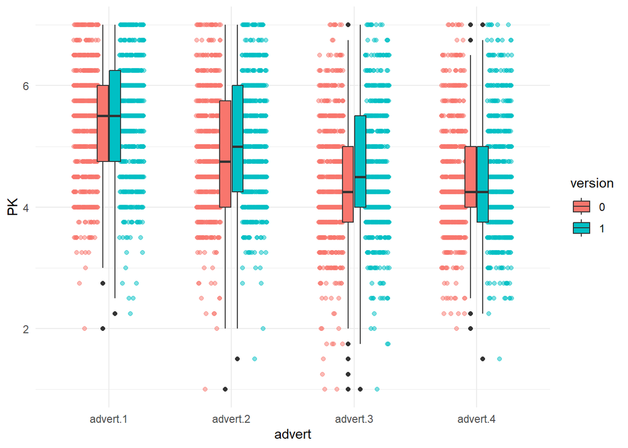

Decriptive bivariate statistics for percieved political goal

| advert | version | n | mean_pg | sd_pg | se_pg | ci_upper | ci_lower |
| --- | --- | --- | --- | --- | --- | --- | --- |
| advert.1 | 0 | 665 | 6.44 | 0.72 | 0.03 | 6.49 | 6.38 |
| advert.1 | 1 | 657 | 6.45 | 0.74 | 0.03 | 6.51 | 6.39 |
| advert.2 | 0 | 657 | 6.35 | 0.86 | 0.03 | 6.41 | 6.28 |
| advert.2 | 1 | 665 | 6.32 | 0.86 | 0.03 | 6.39 | 6.25 |
| advert.3 | 0 | 662 | 5.24 | 1.45 | 0.06 | 5.35 | 5.13 |
| advert.3 | 1 | 660 | 5.43 | 1.36 | 0.05 | 5.53 | 5.32 |
| advert.4 | 0 | 660 | 6.01 | 1.02 | 0.04 | 6.08 | 5.93 |
| advert.4 | 1 | 662 | 6.02 | 1.05 | 0.04 | 6.10 | 5.94 |

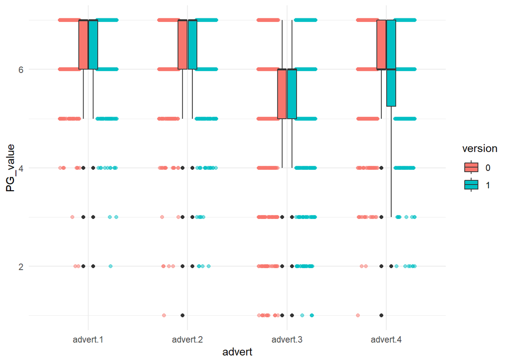

Decriptive bivariate statistics for percieved informedness

| advert | version | n | mean_in | sd_in | se_in | ci_upper | ci_lower |
| --- | --- | --- | --- | --- | --- | --- | --- |
| advert.1 | 0 | 665 | 4.12 | 1.51 | 0.06 | 4.24 | 4.01 |
| advert.1 | 1 | 657 | 4.44 | 1.57 | 0.06 | 4.56 | 4.32 |
| advert.2 | 0 | 657 | 3.69 | 1.59 | 0.06 | 3.82 | 3.57 |
| advert.2 | 1 | 665 | 4.12 | 1.48 | 0.06 | 4.24 | 4.01 |
| advert.3 | 0 | 662 | 3.75 | 1.49 | 0.06 | 3.86 | 3.63 |
| advert.3 | 1 | 660 | 4.11 | 1.53 | 0.06 | 4.23 | 3.99 |
| advert.4 | 0 | 660 | 4.62 | 1.55 | 0.06 | 4.74 | 4.51 |
| advert.4 | 1 | 662 | 4.79 | 1.49 | 0.06 | 4.90 | 4.67 |

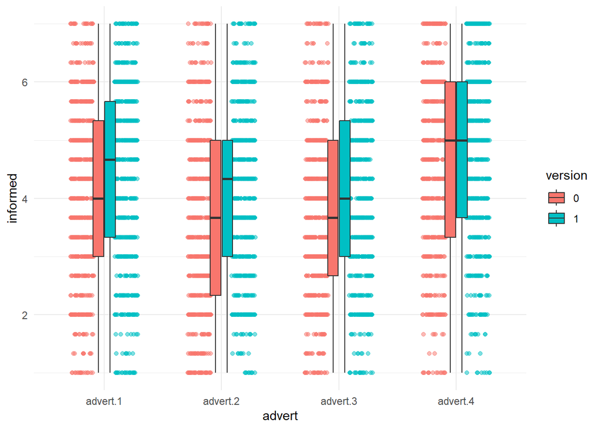

#### Supplementary analysis: digital imprint inclusion and percieved trustworthiness

Did the inclusion of a digital imprint influence how trustworthy and credible the posts were perceived to be?

Outcome: accurate/believable/factual/trustworthy, numerical scale 1-7 Fixed effects: Version of post viewed, binary Random effects: id and advert Control: agreement with post

The models below are created through a function

- model_accurate_value <- lmer(accurate_value ~ version + agree + (1|id) + (1|advert), data = imprint_df)
- model_believable_value <- lmer(believable_value ~ version + agree + (1|id) + (1|advert), data = imprint_df)
- model_factual_value <- lmer(factual_value ~ version + agree + (1|id) + (1|advert), data = imprint_df)
- model_trustworthy_value <- lmer(trustworthy_value ~ version + agree + (1|id) + (1|advert), data = imprint_df)

|  | Percieved accuracy |  |  |
| --- | --- | --- | --- |
| Predictors | Estimates | CI | p |
| Intercept | 0.93 | 0.79 – 1.06 | **<0.001** |
| Digital Imprint included | 0.07 | 0.03 – 0.12 | **0.002** |
| Agreement | 0.72 | 0.70 – 0.73 | **<0.001** |
| Random Effects |  |  |  |
| σ<sup>2</sup> | 0.70 |  |  |
| τ<sub>00</sub> <sub>id</sub> | 0.13 |  |  |
| τ<sub>00</sub> <sub>advert</sub> | 0.01 |  |  |
| ICC | 0.17 |  |  |
| N <sub>id</sub> | 1322 |  |  |
| N <sub>advert</sub> | 4 |  |  |
| Observations | 5288 |  |  |
| Marginal R<sup>2</sup> / Conditional R<sup>2</sup> | 0.584 / 0.655 |  |  |

|  | Percieved believability |  |  |
| --- | --- | --- | --- |
| Predictors | Estimates | CI | p |
| Intercept | 1.29 | 1.08 – 1.50 | **<0.001** |
| Digital Imprint included | 0.06 | 0.01 – 0.11 | **0.013** |
| Agreement | 0.70 | 0.68 – 0.72 | **<0.001** |
| Random Effects |  |  |  |
| σ<sup>2</sup> | 0.83 |  |  |
| τ<sub>00</sub> <sub>id</sub> | 0.24 |  |  |
| τ<sub>00</sub> <sub>advert</sub> | 0.04 |  |  |
| ICC | 0.25 |  |  |
| N <sub>id</sub> | 1322 |  |  |
| N <sub>advert</sub> | 4 |  |  |
| Observations | 5288 |  |  |
| Marginal R<sup>2</sup> / Conditional R<sup>2</sup> | 0.504 / 0.628 |  |  |

|  | Percieved factualness |  |  |
| --- | --- | --- | --- |
| Predictors | Estimates | CI | p |
| Intercept | 0.69 | 0.29 – 1.08 | **0.001** |
| Digital Imprint included | 0.06 | -0.01 – 0.12 | 0.091 |
| Agreement | 0.56 | 0.53 – 0.59 | **<0.001** |
| Random Effects |  |  |  |
| σ<sup>2</sup> | 1.48 |  |  |
| τ<sub>00</sub> <sub>id</sub> | 0.70 |  |  |
| τ<sub>00</sub> <sub>advert</sub> | 0.14 |  |  |
| ICC | 0.36 |  |  |
| N <sub>id</sub> | 1322 |  |  |
| N <sub>advert</sub> | 4 |  |  |
| Observations | 5288 |  |  |
| Marginal R<sup>2</sup> / Conditional R<sup>2</sup> | 0.238 / 0.514 |  |  |

|  | Percieved trustworthiness |  |  |
| --- | --- | --- | --- |
| Predictors | Estimates | CI | p |
| Intercept | 0.85 | 0.55 – 1.15 | **<0.001** |
| Digital Imprint included | 0.08 | 0.04 – 0.13 | **0.001** |
| Agreement | 0.61 | 0.59 – 0.63 | **<0.001** |
| Random Effects |  |  |  |
| σ<sup>2</sup> | 0.81 |  |  |
| τ<sub>00</sub> <sub>id</sub> | 0.30 |  |  |
| τ<sub>00</sub> <sub>advert</sub> | 0.08 |  |  |
| ICC | 0.32 |  |  |
| N <sub>id</sub> | 1322 |  |  |
| N <sub>advert</sub> | 4 |  |  |
| Observations | 5288 |  |  |
| Marginal R<sup>2</sup> / Conditional R<sup>2</sup> | 0.421 / 0.607 |  |  |

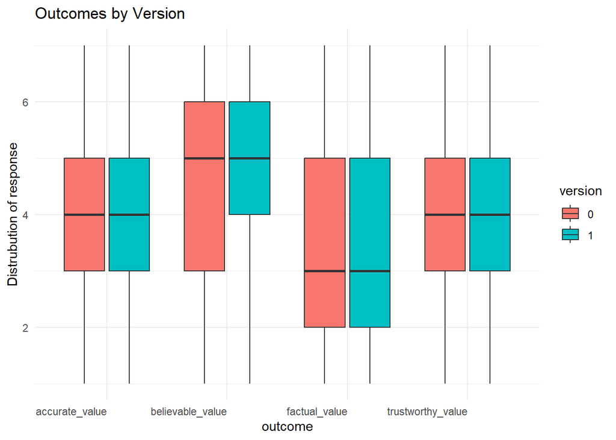

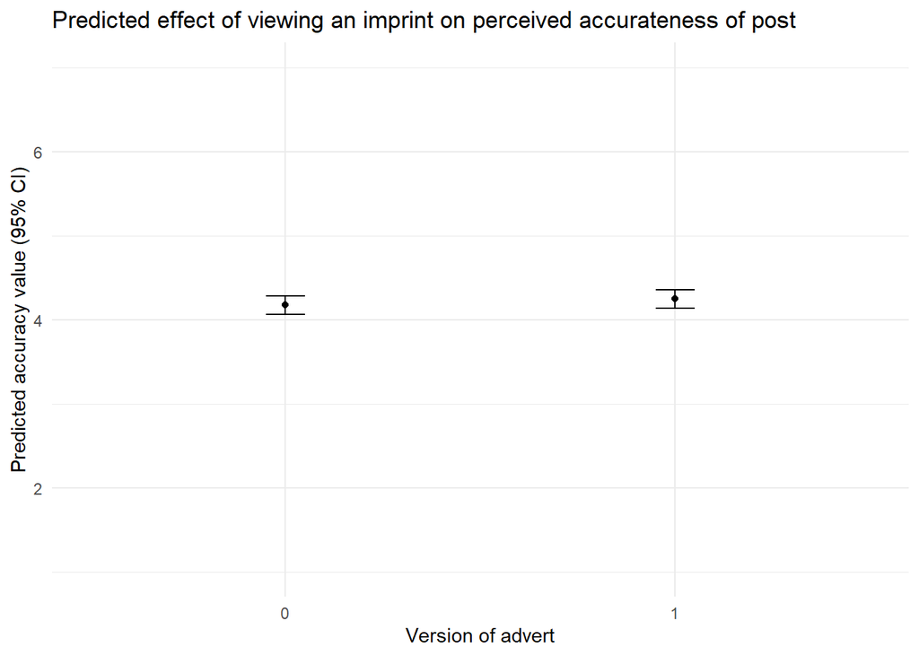

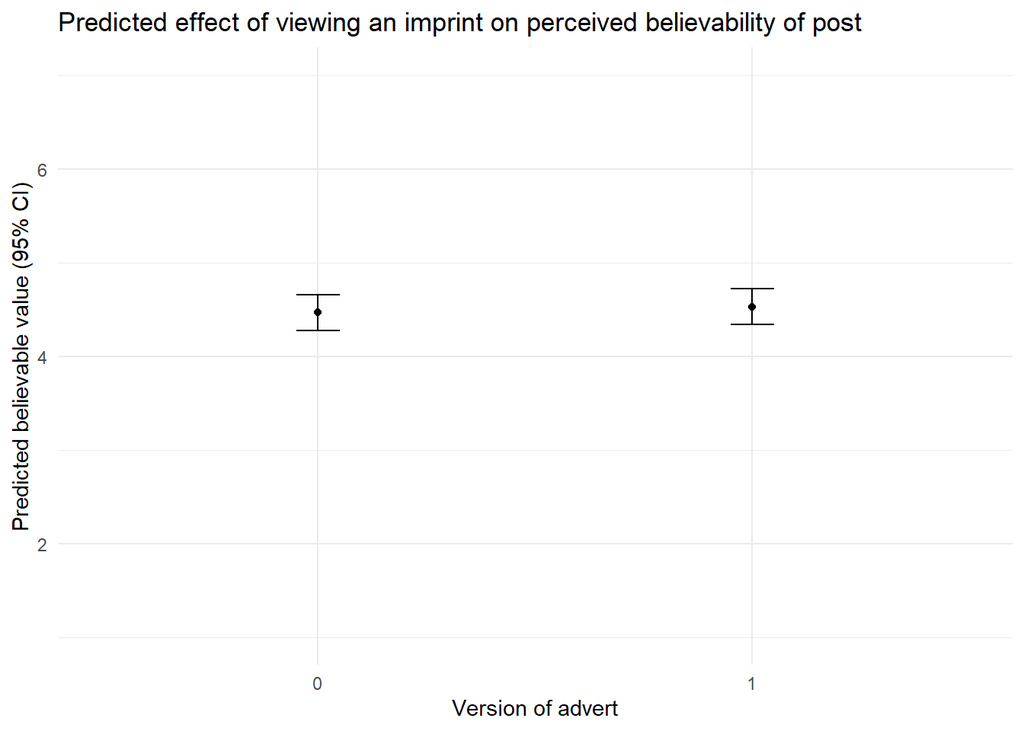

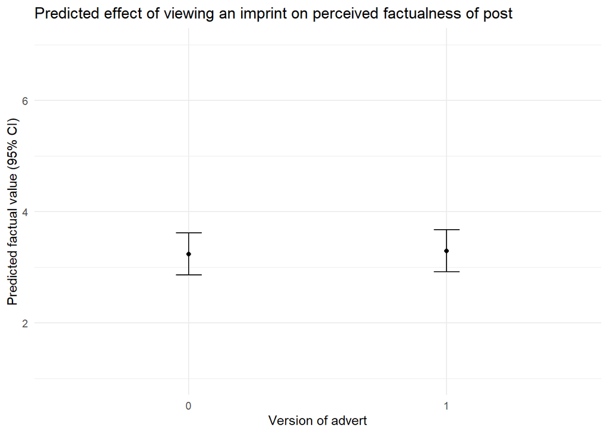

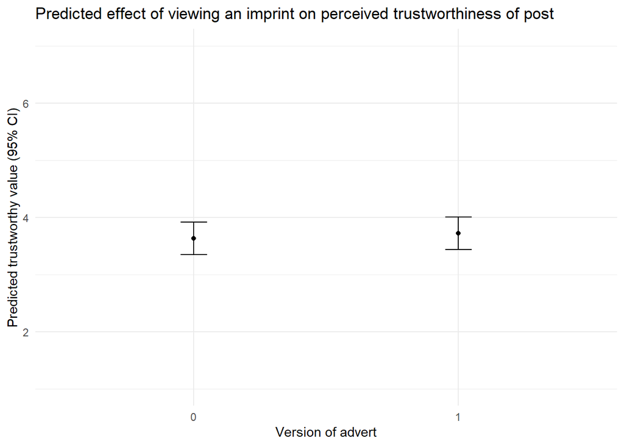

Checking assumptions for trustworthy:

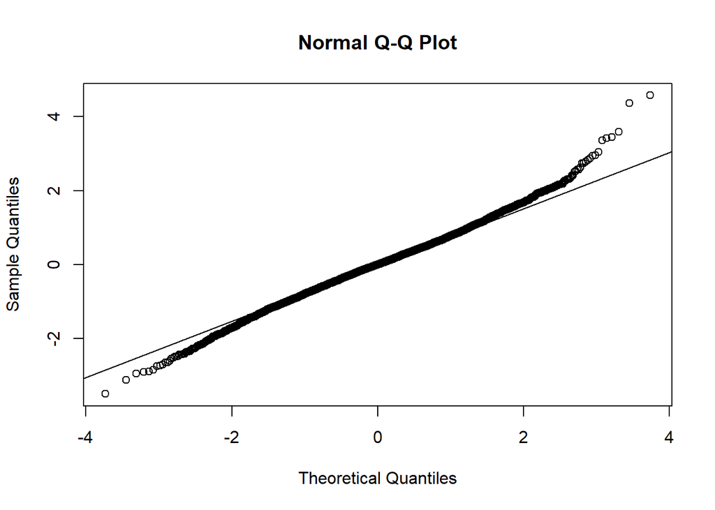

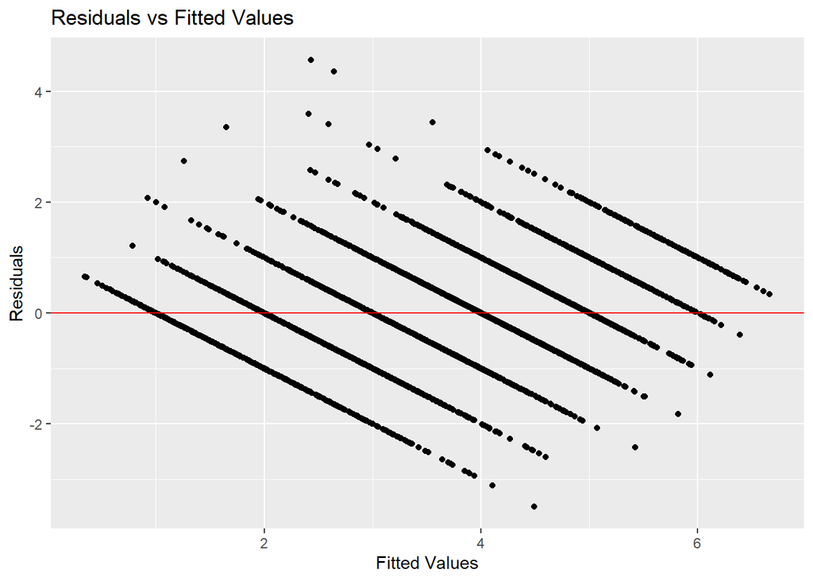

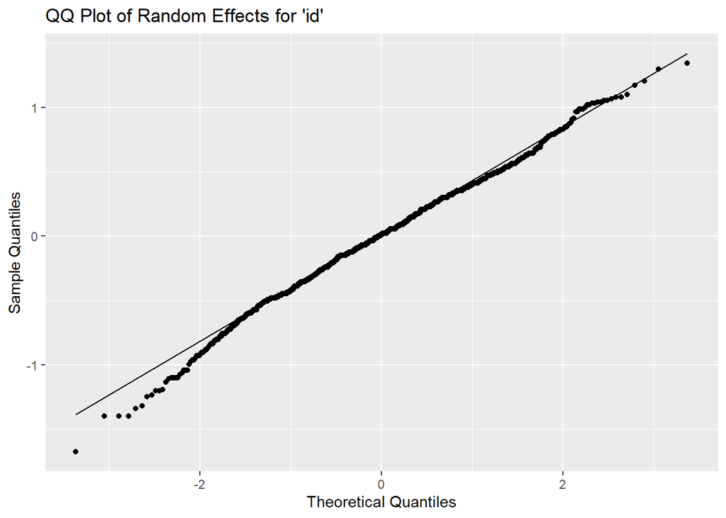

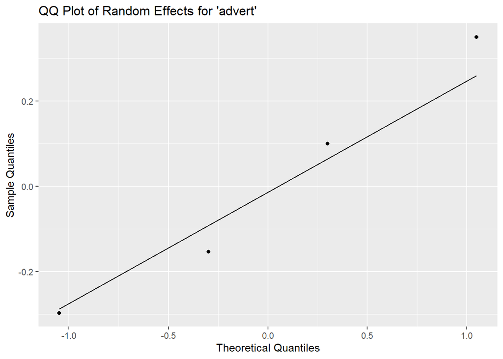

```
##
##  Shapiro-Wilk normality test
##
## data:  id_effects
## W = 0.99474, p-value = 0.0001368
```

```
##
##  Shapiro-Wilk normality test
##
## data:  advert_effects
## W = 0.9701, p-value = 0.8421
```

### Hypothesis 2a: outcome: correct name recall

Did participants recall a higher number of correct campaigner names when they are trained to pay attention to the source?

#### Model

```r
correct_name <- lm(name_correct ~ Training.condition, data = training_df)
```

#### Table

|  | Number of names correctly recalled |  |  |
| --- | --- | --- | --- |
| Predictors | Estimates | CI | p |
| Intercept | 2.10 | 2.01 – 2.18 | **<0.001** |
| Trained | 0.18 | 0.06 – 0.29 | **0.004** |
| Observations | 1322 |  |  |
| R<sup>2</sup> / R<sup>2</sup> adjusted | 0.006 / 0.006 |  |  |

#### Plotting: Raw data

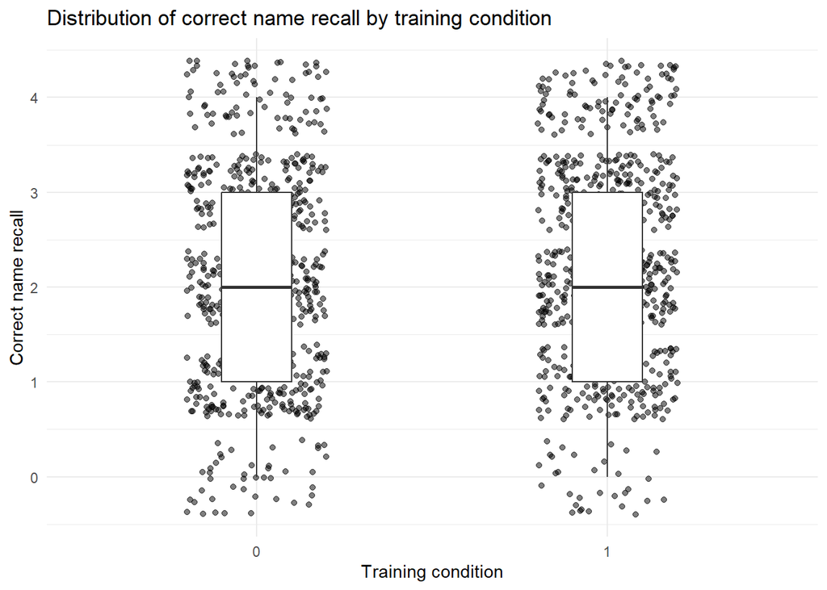

#### Plotting: Model predictions

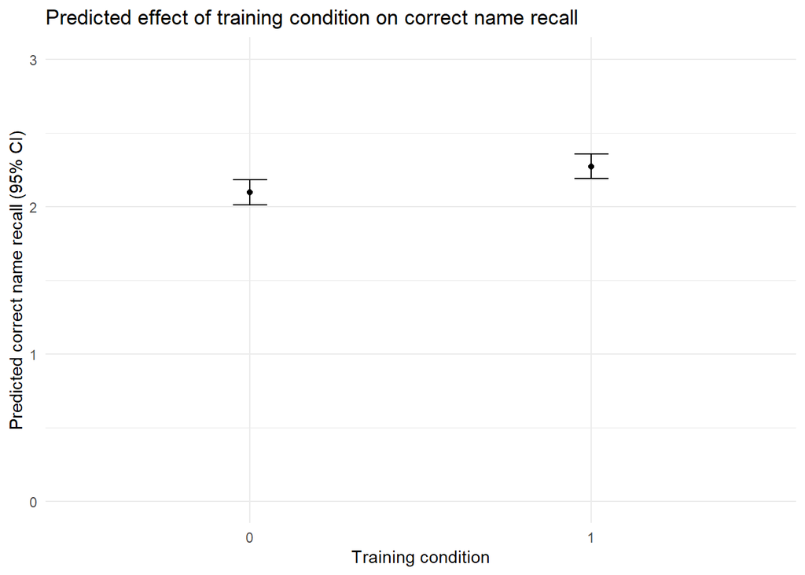

#### Assumptions

As there is only 1 binary predictor, there is no need to assess linearity as it only assumes a difference in total means for each group. Assessed is:

- Normality of residuals
- Equal variance of residuals

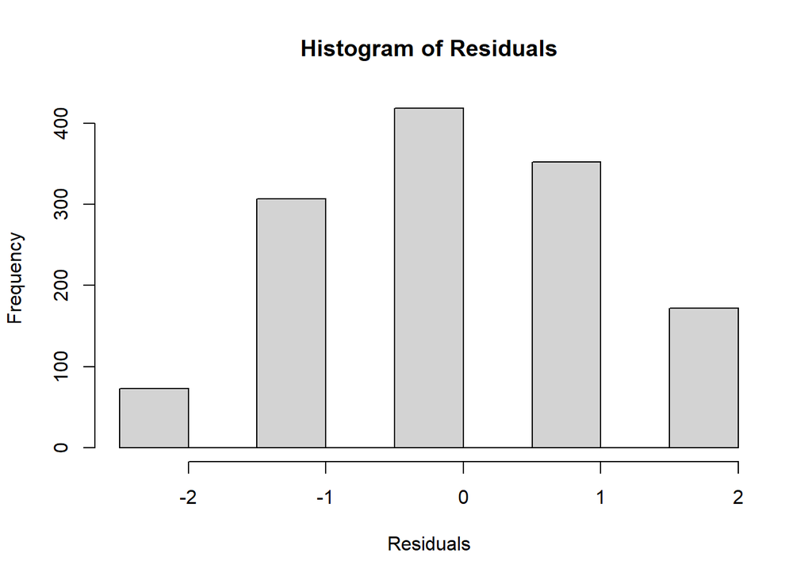

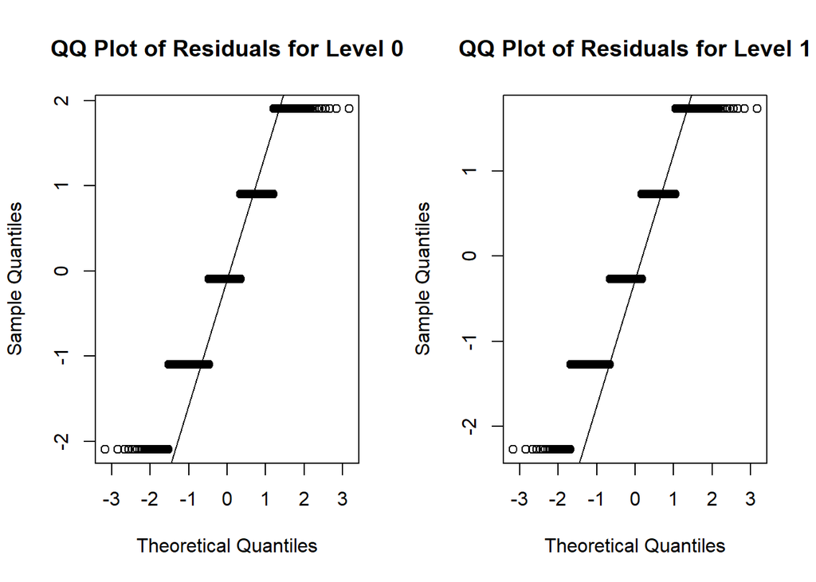

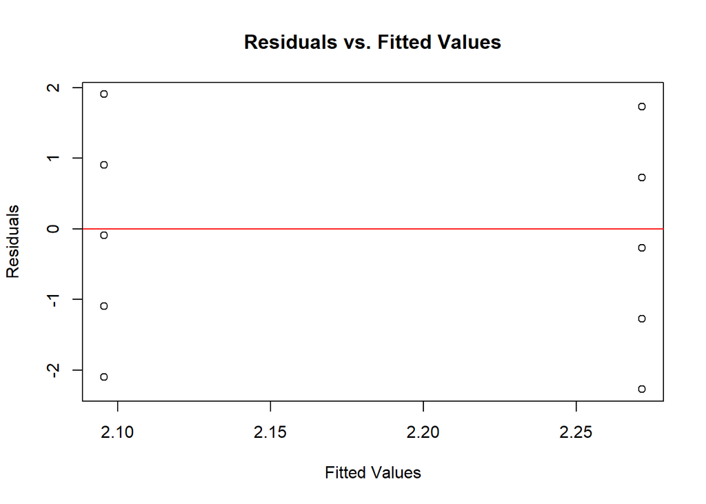

### Hypothesis 2b: outcome: percieved informedness

Were trained participants more likely to correctly identify that they were less informed when a digital imprint was *not* present, and more informed when a digital imprint was present, compared to the group who received no training?

#### Model

- Outcome: perceived informedness, numerical 1-7
- fixed effect: training condition x version of imprint viewed (interaction effect)
- random effects: id and advert

```r
inform_training <- lmer(informed ~ Training.condition + version + Training.condition*version + (1|id) + (1|advert), data = imprint_df)
```

#### Table

|  | Perceived Informedness |  |  |
| --- | --- | --- | --- |
| Predictors | Estimates | CI | p |
| Intercept | 4.08 | 3.71 – 4.46 | **<0.001** |
| Training | -0.07 | -0.20 – 0.06 | 0.296 |
| Digital Imprint included | 0.21 | 0.11 – 0.31 | **<0.001** |
| Training*imprint | 0.22 | 0.08 – 0.36 | **0.002** |
| Random Effects |  |  |  |
| σ<sup>2</sup> | 1.71 |  |  |
| τ<sub>00</sub> <sub>id</sub> | 0.62 |  |  |
| τ<sub>00</sub> <sub>advert</sub> | 0.14 |  |  |
| ICC | 0.31 |  |  |
| N <sub>id</sub> | 1322 |  |  |
| N <sub>advert</sub> | 4 |  |  |
| Observations | 5288 |  |  |
| Marginal R<sup>2</sup> / Conditional R<sup>2</sup> | 0.011 / 0.313 |  |  |

#### Plotting: Raw data

Decriptive bivariate statistics for percieved informedness

| Training.condition | version | n | mean_informed | sd_informed | se_informed | ci_upper | ci_lower |
| --- | --- | --- | --- | --- | --- | --- | --- |
| 0 | 0 | 1318 | 4.08 | 1.56 | 0.04 | 4.17 | 4.00 |
| 0 | 1 | 1318 | 4.29 | 1.54 | 0.04 | 4.37 | 4.20 |
| 1 | 0 | 1326 | 4.01 | 1.60 | 0.04 | 4.10 | 3.92 |
| 1 | 1 | 1326 | 4.44 | 1.54 | 0.04 | 4.53 | 4.36 |

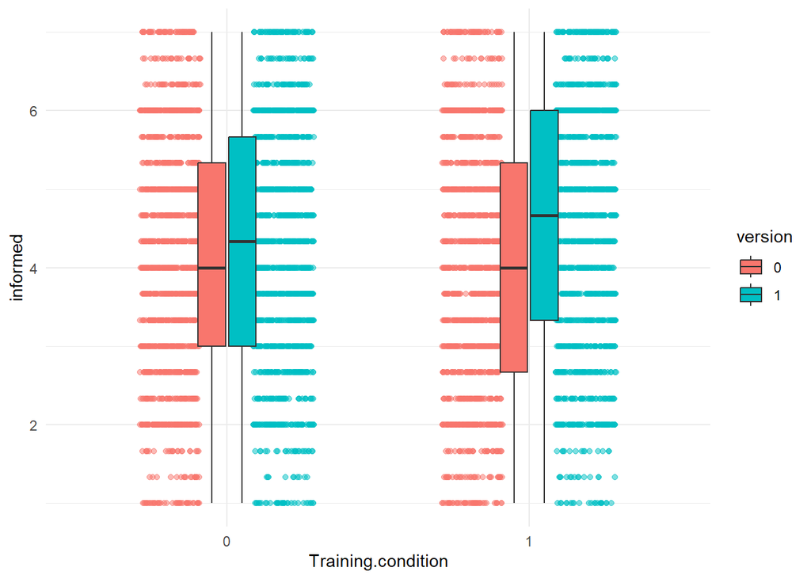

#### Plotting: Model predictions

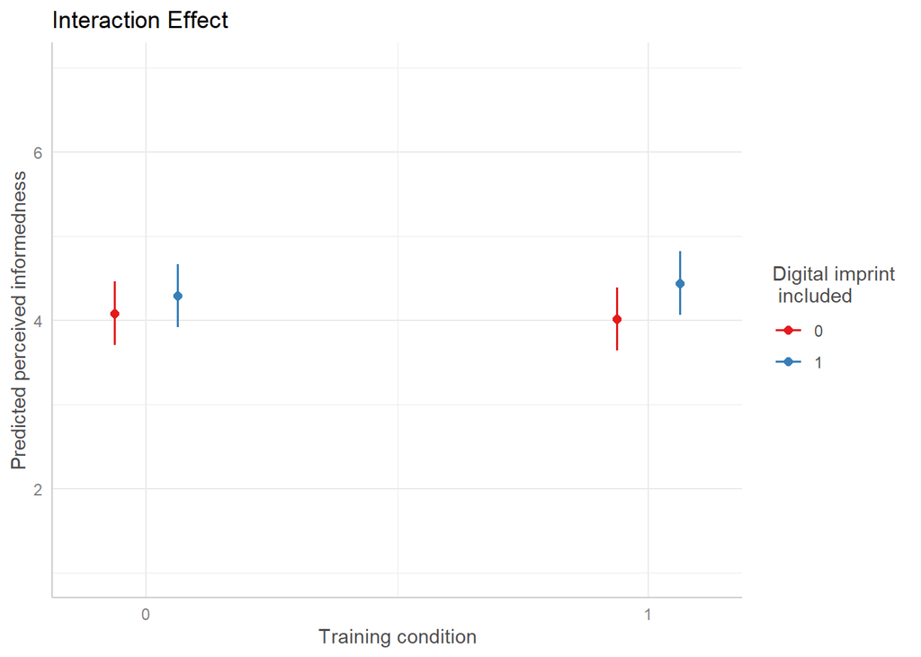

#### Assumptions

The following assumptions are checked:

- Normality of residuals
- Variance of residuals
- Normality of residuals within the random effects

There are no key assumption violations, supporting that the model predictions are reliable.

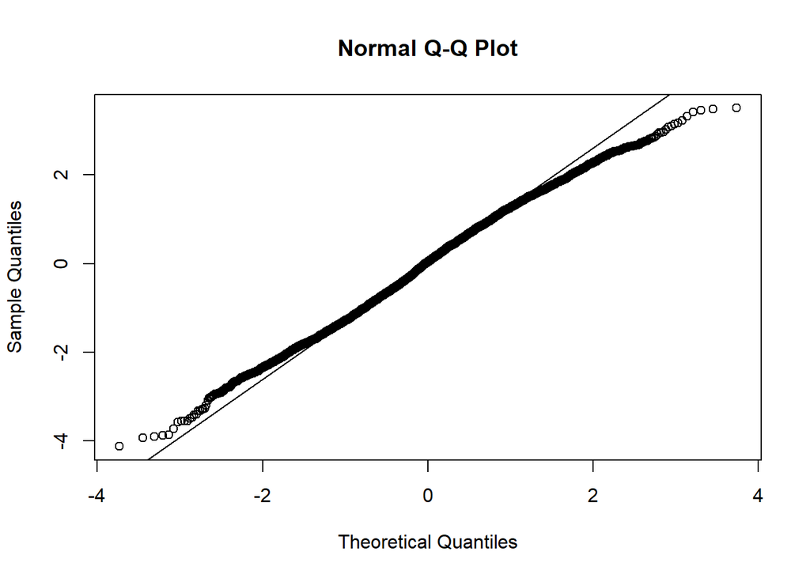

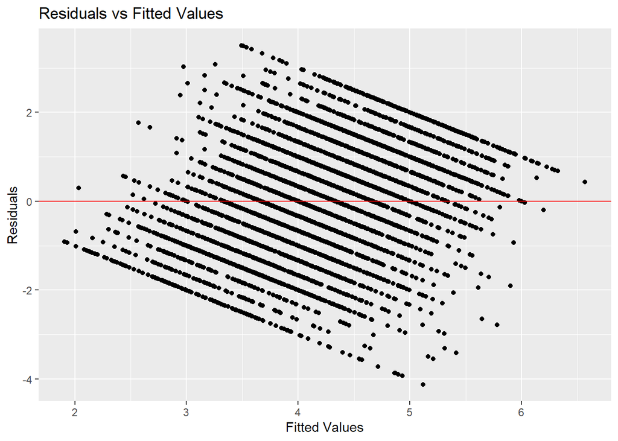

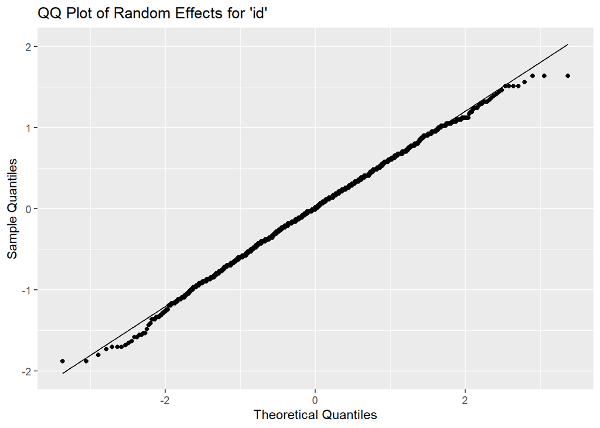

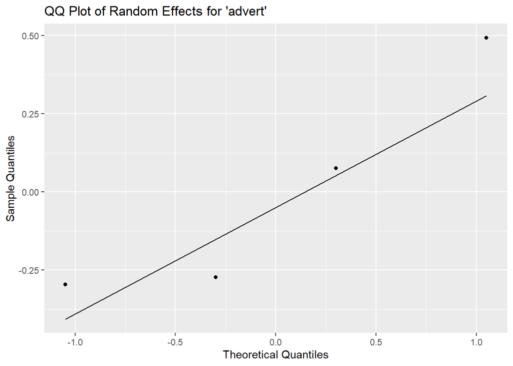

```
##
##  Shapiro-Wilk normality test
##
## data:  id_effects
## W = 0.99765, p-value = 0.05214
```

```
##
##  Shapiro-Wilk normality test
##
## data:  advert_effects
## W = 0.87633, p-value = 0.3232
```

### Hypothesis 3: outcome: trustworthiness

Did those informed about the purpose of imprints use their absence/presence to evaluate the trustworthiness and credibility of the posts?

- Outcome: accurate/factual/believable/trustworthy, numerical 1-7
- fixed effect: training condition x version of imprint viewed (interaction effect)
- random effects: id and advert
- control: agreement with post

#### Models

Four models are created through the use of a function for each of the outcome variables, using the following forumula:

model <- lmer(outcome ~ Training.condition + version + agree_value + Training.condition*version + (1|id) + (1|advert))

#### Tables

|  | Perceived trustworthiness |  |  |
| --- | --- | --- | --- |
| Predictors | Estimates | CI | p |
| Intercept | 0.87 | 0.57 – 1.18 | **<0.001** |
| Training | -0.05 | -0.14 – 0.04 | 0.266 |
| Digital Imprint included | 0.07 | -0.00 – 0.14 | 0.057 |
| Agreement | 0.61 | 0.59 – 0.63 | **<0.001** |
| Training*imprint | 0.03 | -0.06 – 0.13 | 0.481 |
| Random Effects |  |  |  |
| σ<sup>2</sup> | 0.81 |  |  |
| τ<sub>00</sub> <sub>id</sub> | 0.30 |  |  |
| τ<sub>00</sub> <sub>advert</sub> | 0.08 |  |  |
| ICC | 0.32 |  |  |
| N <sub>id</sub> | 1322 |  |  |
| N <sub>advert</sub> | 4 |  |  |
| Observations | 5288 |  |  |
| Marginal R<sup>2</sup> / Conditional R<sup>2</sup> | 0.421 / 0.607 |  |  |

|  | Perceived believability |  |  |
| --- | --- | --- | --- |
| Predictors | Estimates | CI | p |
| Intercept | 1.28 | 1.07 – 1.50 | **<0.001** |
| Training | 0.01 | -0.08 – 0.10 | 0.849 |
| Digital Imprint included | 0.06 | -0.01 – 0.13 | 0.104 |
| Agreement | 0.70 | 0.68 – 0.72 | **<0.001** |
| Training*imprint | 0.01 | -0.09 – 0.11 | 0.851 |
| Random Effects |  |  |  |
| σ<sup>2</sup> | 0.83 |  |  |
| τ<sub>00</sub> <sub>id</sub> | 0.24 |  |  |
| τ<sub>00</sub> <sub>advert</sub> | 0.04 |  |  |
| ICC | 0.25 |  |  |
| N <sub>id</sub> | 1322 |  |  |
| N <sub>advert</sub> | 4 |  |  |
| Observations | 5288 |  |  |
| Marginal R<sup>2</sup> / Conditional R<sup>2</sup> | 0.504 / 0.628 |  |  |

|  | Perceived accuracy |  |  |
| --- | --- | --- | --- |
| Predictors | Estimates | CI | p |
| Intercept | 0.93 | 0.79 – 1.07 | **<0.001** |
| Training | -0.01 | -0.08 – 0.07 | 0.802 |
| Digital Imprint included | 0.05 | -0.02 – 0.11 | 0.138 |
| Agreement | 0.72 | 0.70 – 0.73 | **<0.001** |
| Training*imprint | 0.05 | -0.04 – 0.14 | 0.297 |
| Random Effects |  |  |  |
| σ<sup>2</sup> | 0.70 |  |  |
| τ<sub>00</sub> <sub>id</sub> | 0.13 |  |  |
| τ<sub>00</sub> <sub>advert</sub> | 0.01 |  |  |
| ICC | 0.17 |  |  |
| N <sub>id</sub> | 1322 |  |  |
| N <sub>advert</sub> | 4 |  |  |
| Observations | 5288 |  |  |
| Marginal R<sup>2</sup> / Conditional R<sup>2</sup> | 0.584 / 0.655 |  |  |

|  | Perceived fact versus opinion |  |  |
| --- | --- | --- | --- |
| Predictors | Estimates | CI | p |
| Intercept | 0.69 | 0.29 – 1.10 | **0.001** |
| Training | -0.01 | -0.14 – 0.12 | 0.849 |
| Digital Imprint included | 0.02 | -0.07 – 0.12 | 0.603 |
| Agreement | 0.56 | 0.53 – 0.59 | **<0.001** |
| Training*imprint | 0.06 | -0.07 – 0.19 | 0.343 |
| Random Effects |  |  |  |
| σ<sup>2</sup> | 1.48 |  |  |
| τ<sub>00</sub> <sub>id</sub> | 0.70 |  |  |
| τ<sub>00</sub> <sub>advert</sub> | 0.14 |  |  |
| ICC | 0.36 |  |  |
| N <sub>id</sub> | 1322 |  |  |
| N <sub>advert</sub> | 4 |  |  |
| Observations | 5288 |  |  |
| Marginal R<sup>2</sup> / Conditional R<sup>2</sup> | 0.238 / 0.514 |  |  |

#### Plotting: raw data

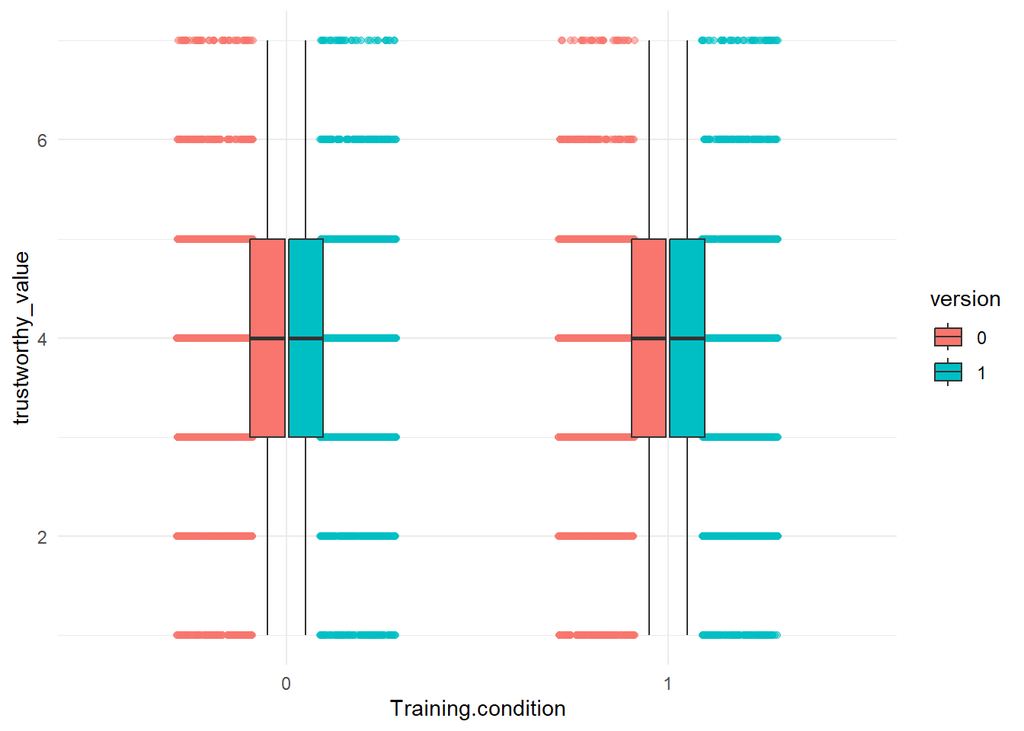

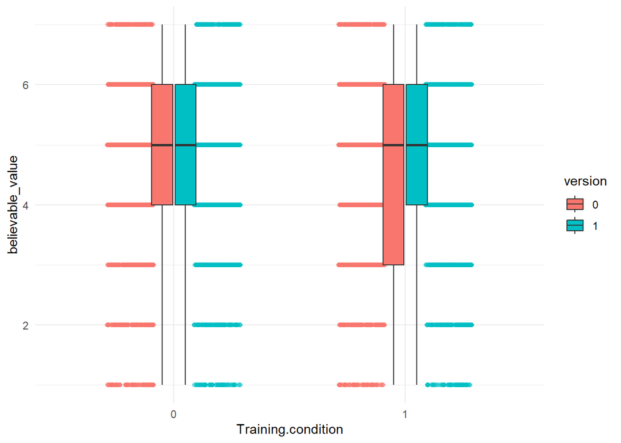

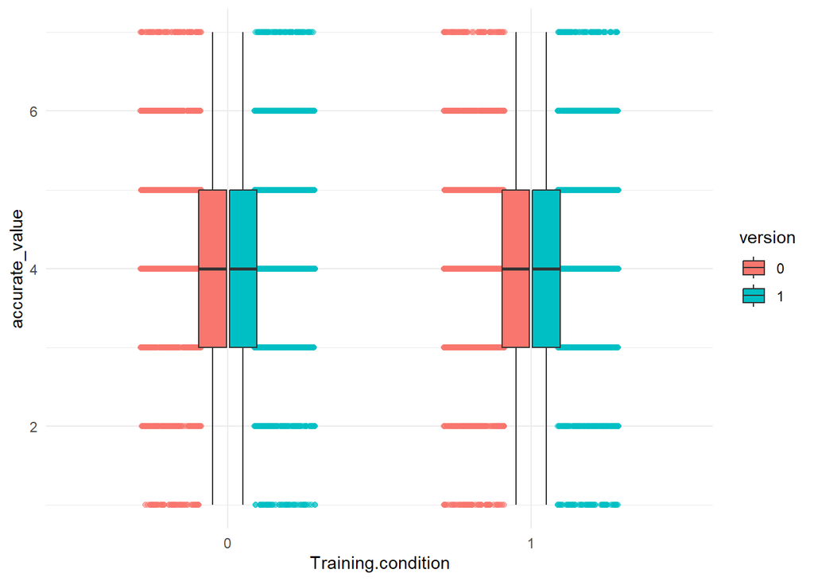

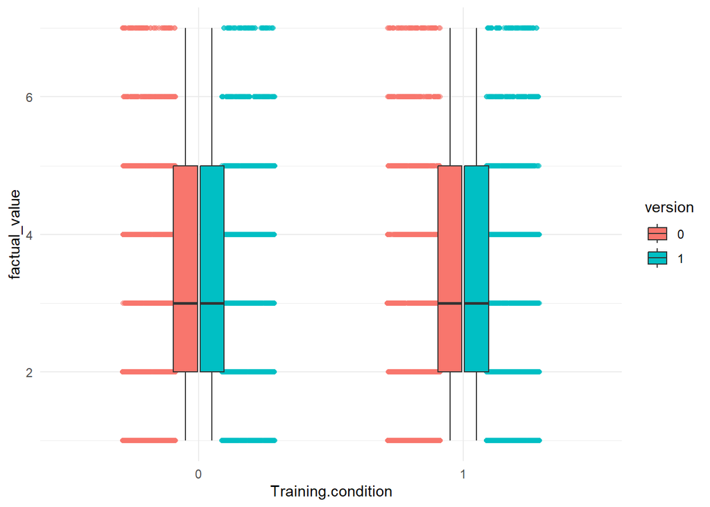

#### Plotting: model predictions

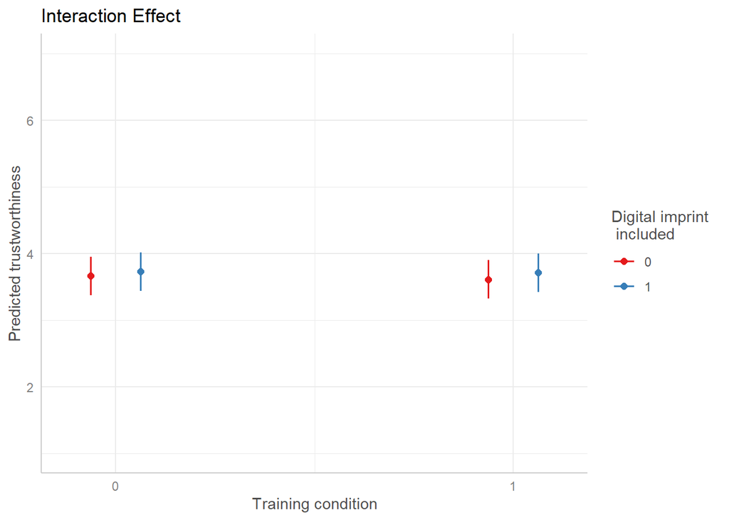

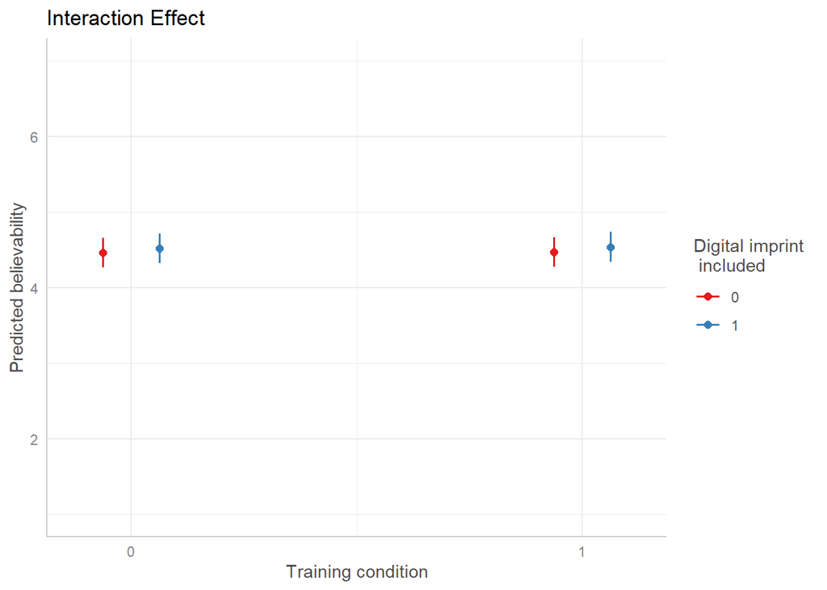

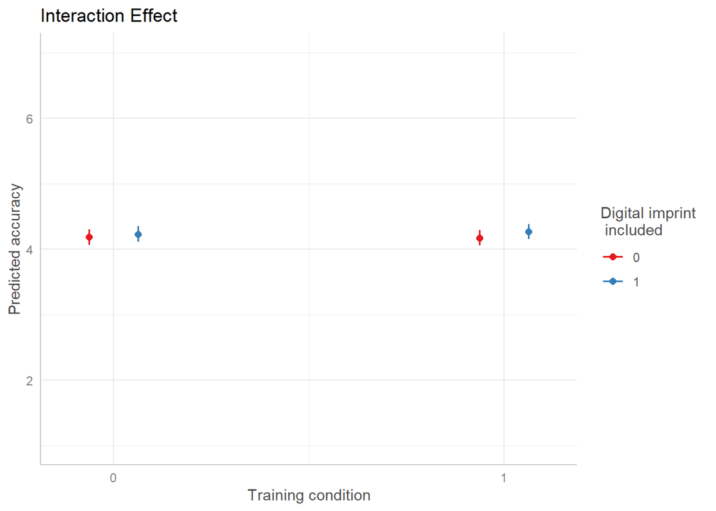

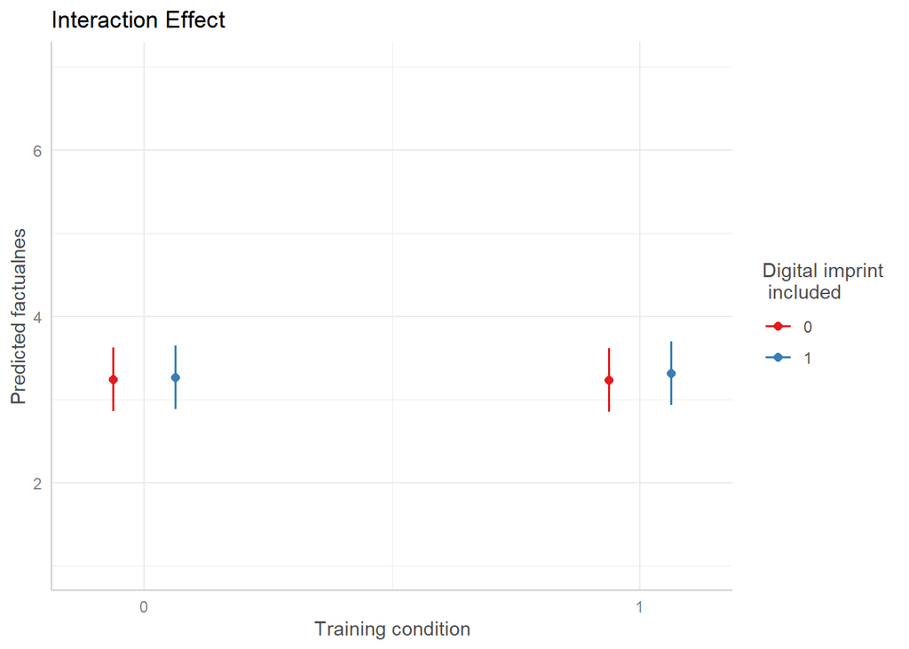

#### Assumptions

Each model is checked for the following assumptions:

- normality of residuals
- equal variance of residuals
- normal distribution of residuals for the random effects

As can be seen, the assumptions are not met for many of the models, creating a need for robustness checks. Additionally, in the supplementary check for the effect of digital imprints on trustworthiness, the effect of imprints is small but positive and significant across the outcomes: trustworthiness, accuracy and believability. This significance is not maintained in the models tested for hypothesis 3 that include the training condition and an interaction effect. Comparisons of model fit between these models suggest they are similar, but this stresses the need for caution when interpreting these models and additional checks.

Trustworthy model:

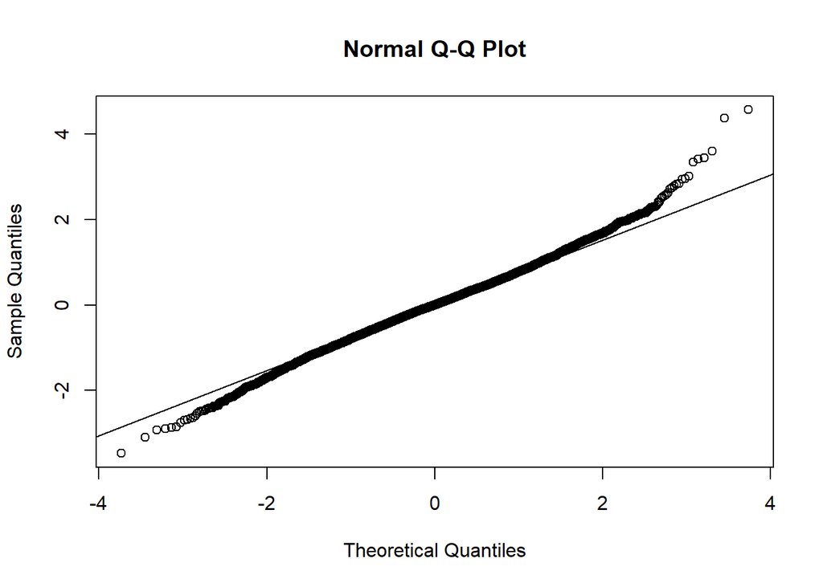

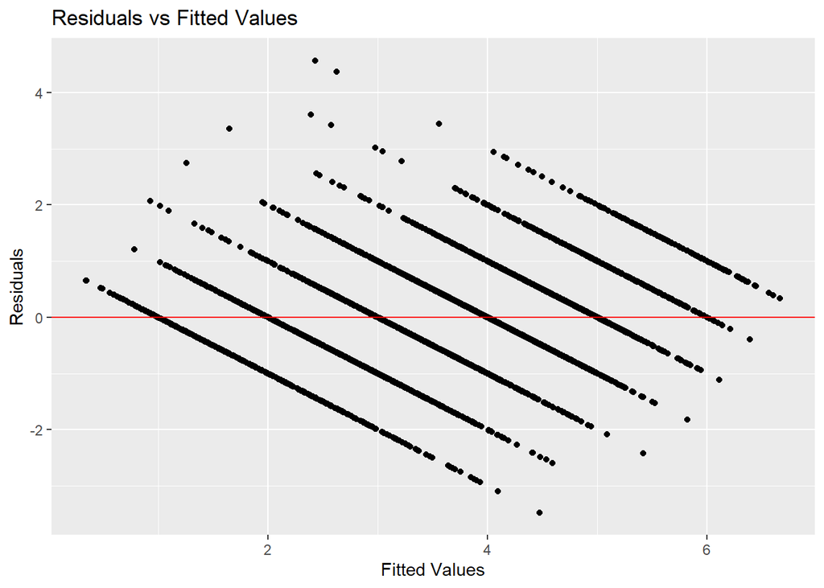

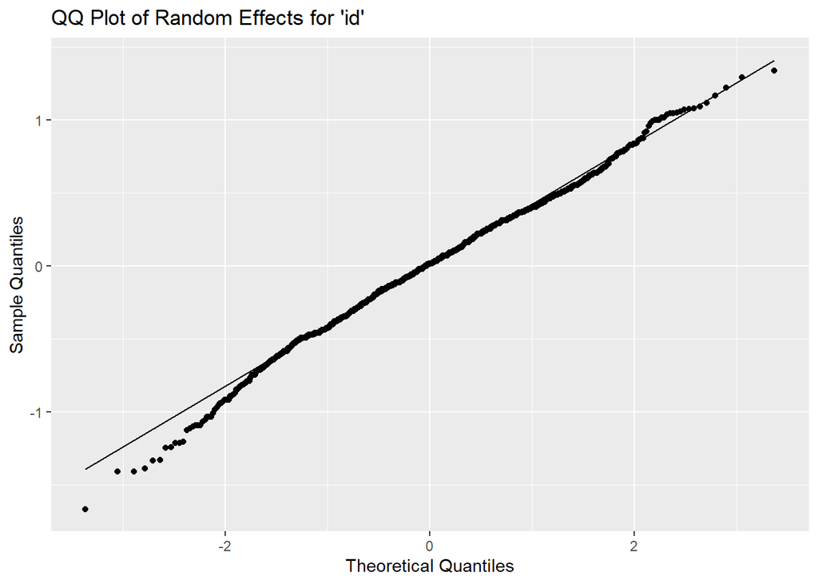

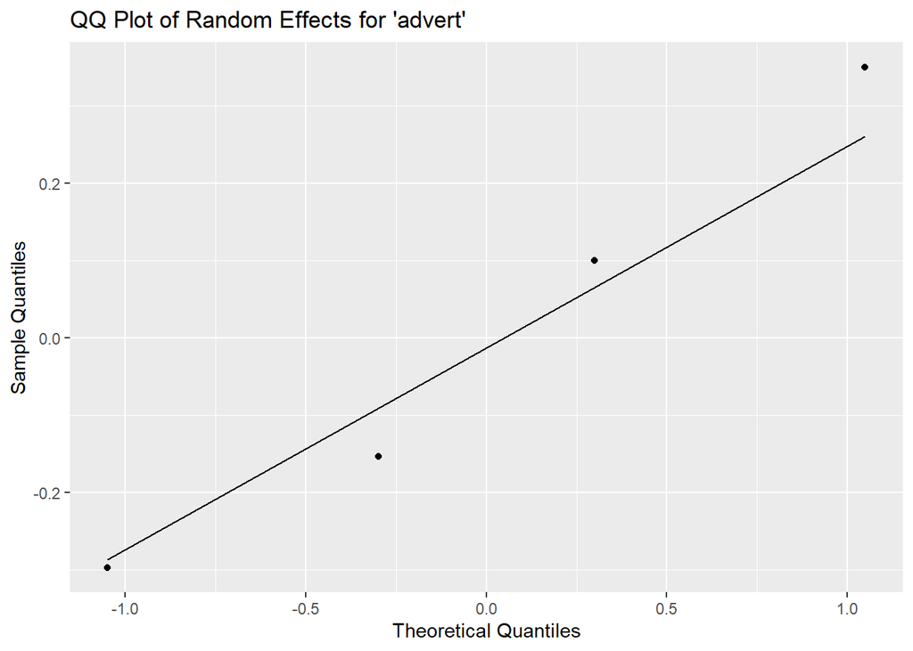

```
##
##  Shapiro-Wilk normality test
##
## data:  id_effects
## W = 0.99468, p-value = 0.0001214
```

```
##
##  Shapiro-Wilk normality test
##
## data:  advert_effects
## W = 0.97023, p-value = 0.8429
```

Believable model:

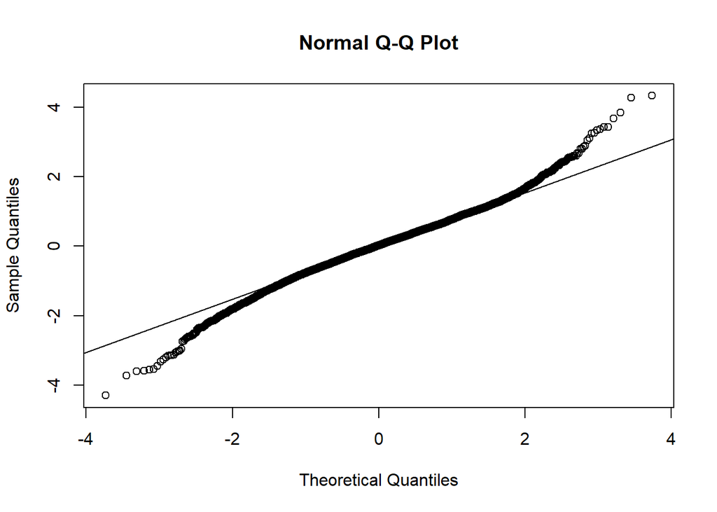

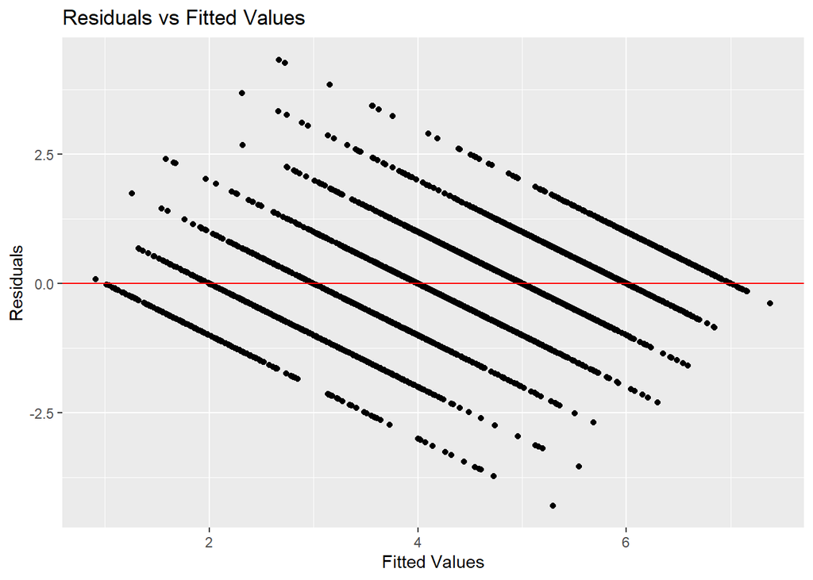

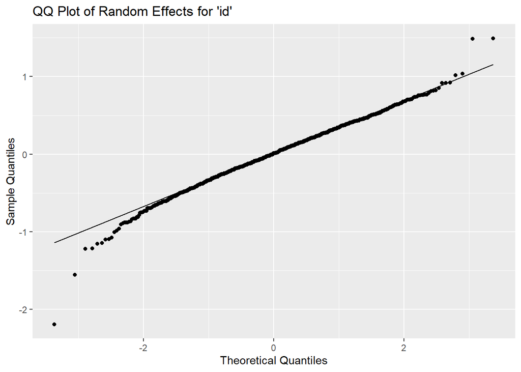

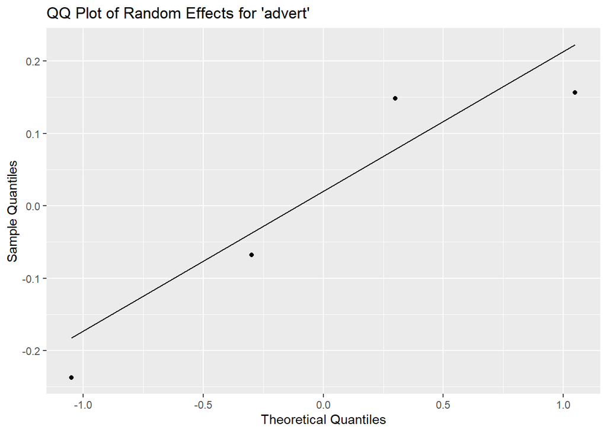

```
##
##  Shapiro-Wilk normality test
##
## data:  id_effects
## W = 0.98784, p-value = 4.752e-09
```

```
##
##  Shapiro-Wilk normality test
##
## data:  advert_effects
## W = 0.87462, p-value = 0.3162
```

Accurate model:

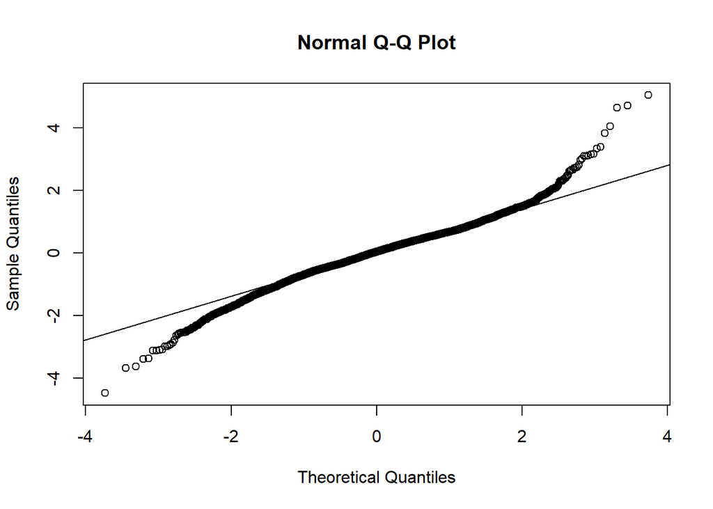

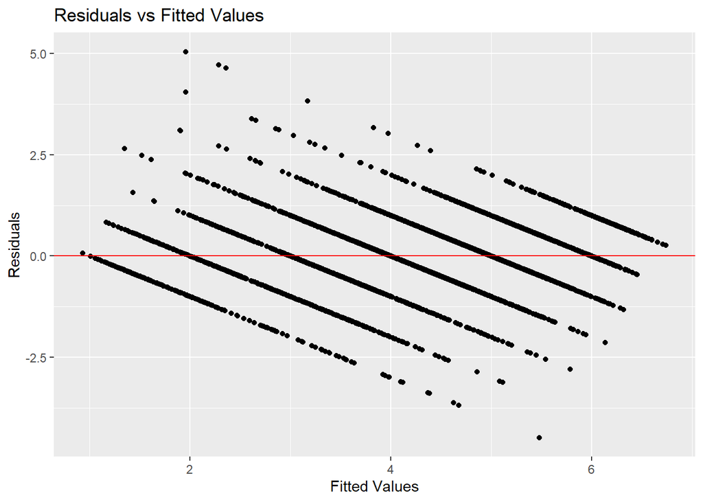

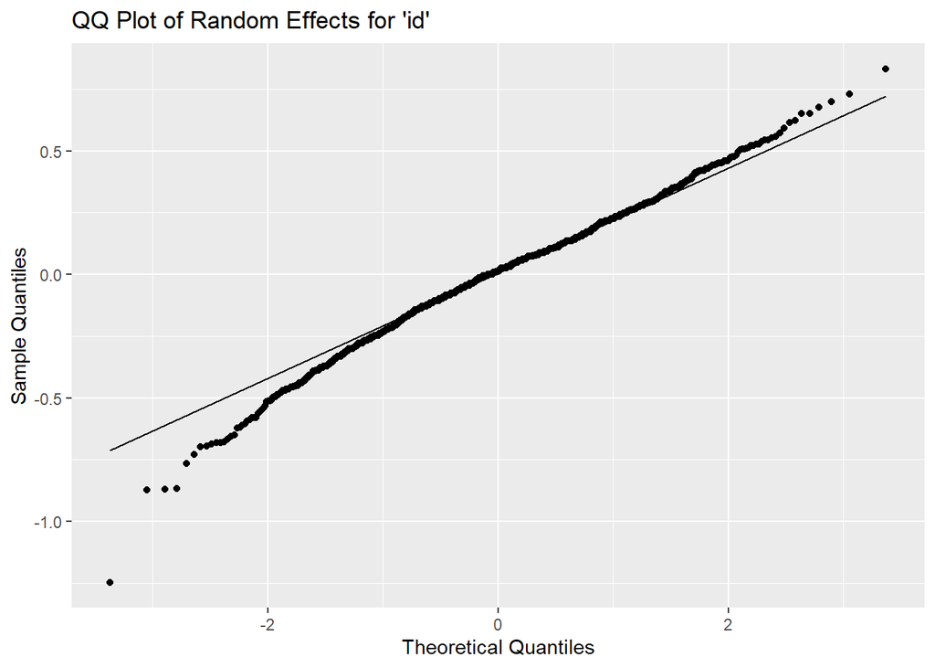

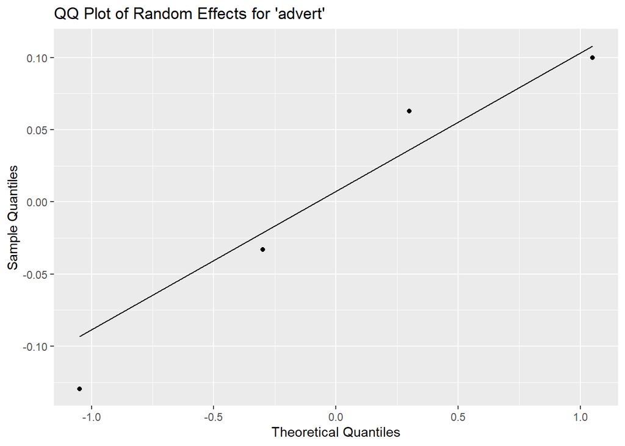

```
##
##  Shapiro-Wilk normality test
##
## data:  id_effects
## W = 0.9901, p-value = 8.823e-08
```

```
##
##  Shapiro-Wilk normality test
##
## data:  advert_effects
## W = 0.9477, p-value = 0.7018
```

Factual model:

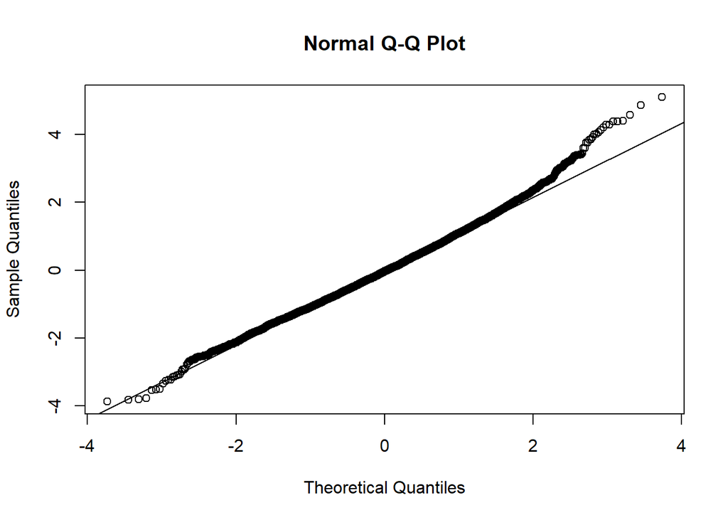

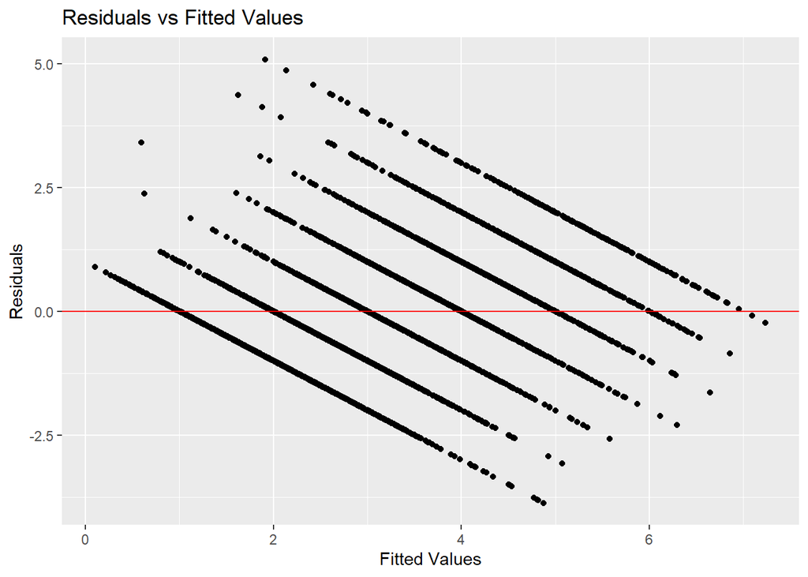

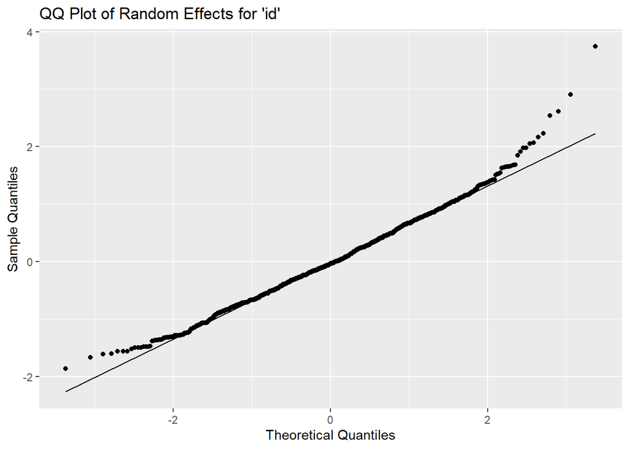

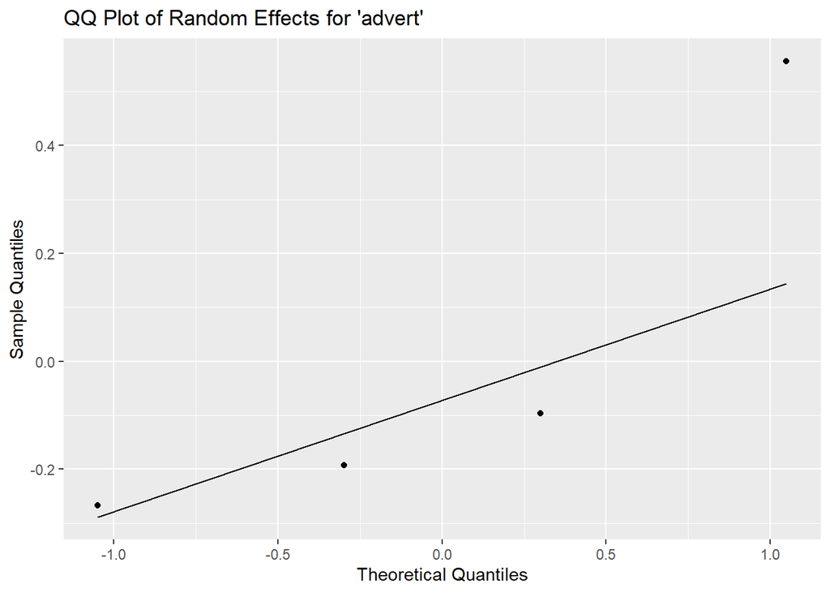

```
##
##  Shapiro-Wilk normality test
##
## data:  id_effects
## W = 0.98918, p-value = 2.582e-08
```

```
##
##  Shapiro-Wilk normality test
##
## data:  advert_effects
## W = 0.79159, p-value = 0.08797
```

### Hypothesis 4: outcome: confidence in regulation

Does being informed explicitly about the purpose of digital imprints and their relation to regulatory compliance increase perceptions that political advertising is sufficiently regulated in the UK?

This model uses the training_df dataframe.

- Outcome: confidence in regulation, numerical 1-7
- Predictor: training condition

#### Model

```r
regulation_model <- lm(election_reg ~ Training.condition, data = training_df)
```

#### Table

|  | Perceived sufficiency of advertising regulation |  |  |
| --- | --- | --- | --- |
| Predictors | Estimates | CI | p |
| Intercept | 3.01 | 2.90 – 3.12 | **<0.001** |
| Trained | -0.11 | -0.27 – 0.04 | 0.150 |
| Observations | 1322 |  |  |
| R<sup>2</sup> / R<sup>2</sup> adjusted | 0.002 / 0.001 |  |  |

#### Plotting: raw data

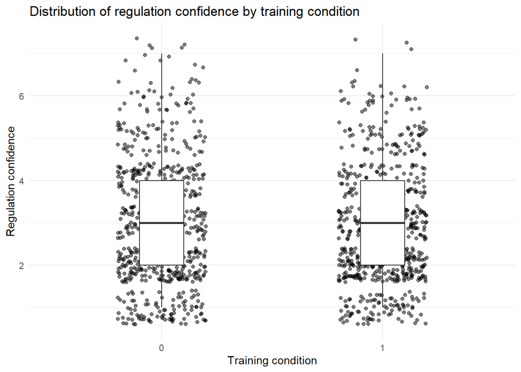

#### Plotting: model predictions

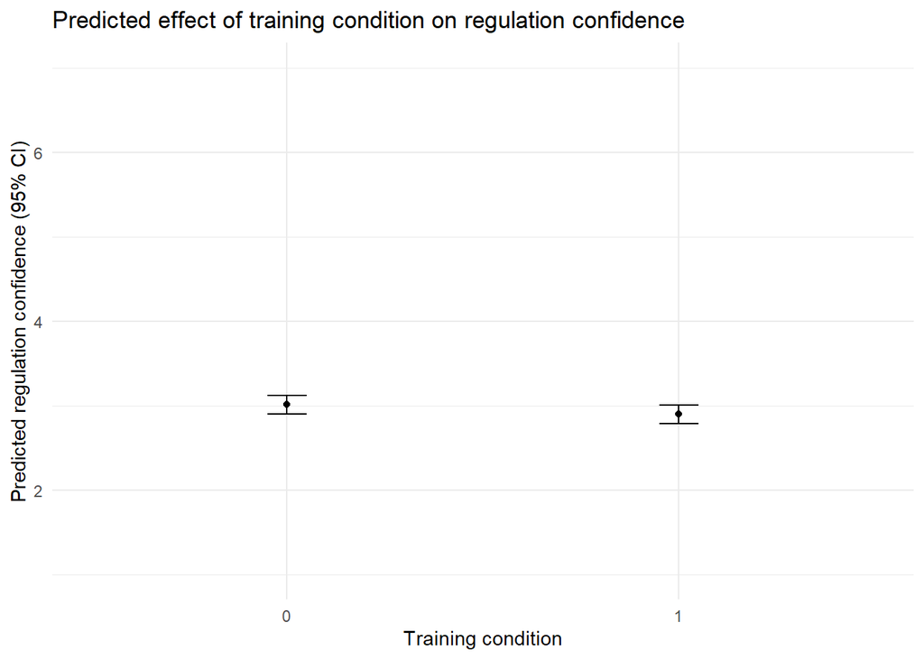

#### Model assumptions

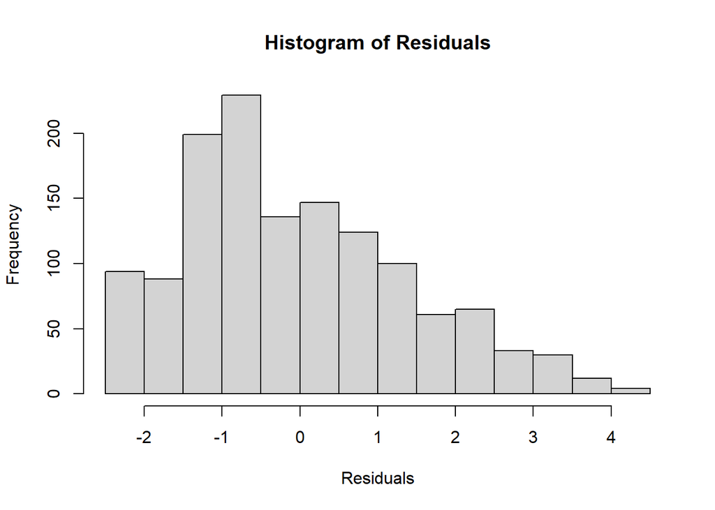

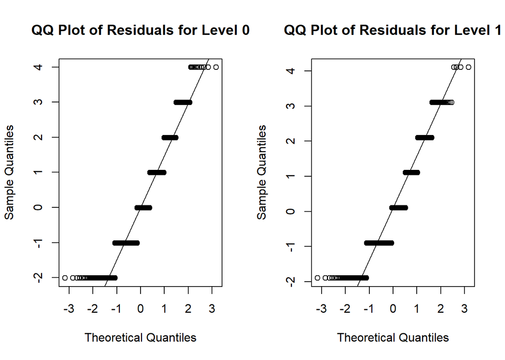

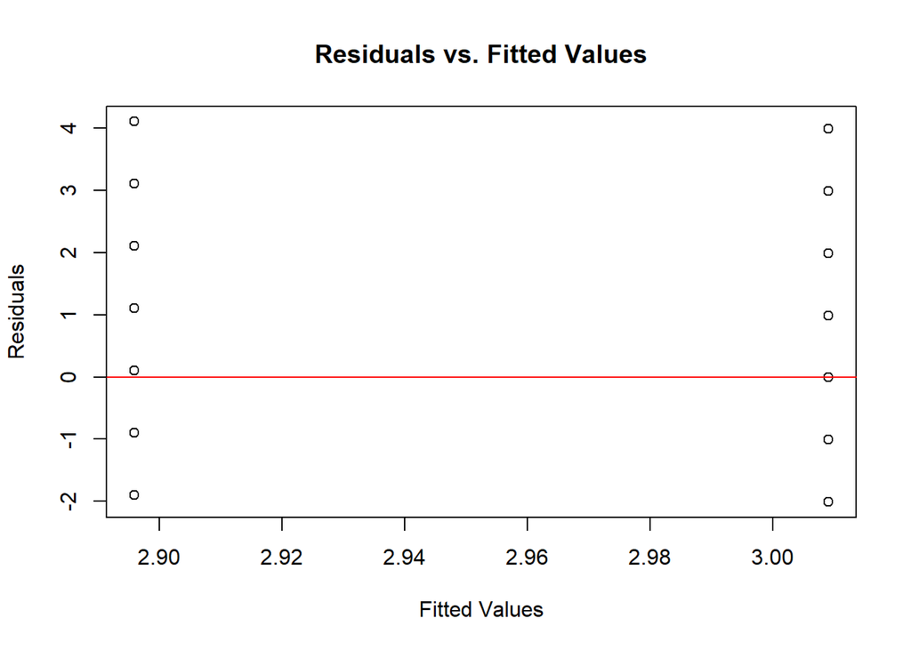